# Employee Attrition

Aug 2019

## Problem Statement

Attrition:

- problem that impacts all businesses
- leads to significant costs for a business
- including the cost of business disruption, hiring new staff and training new staff.
- underderstanding the drivers is crucial
- classification models to predict if an employee is likely to quit could greatly increase HR’s ability to intervene on time and remedy the situation to prevent attrition.

## Dataset

- \(n = 1470\) employees and some of their attributes (selection below):

| Name | Description |
| --- | --- |
| AGE | Numerical Value |
| GENDER | (1=FEMALE, 2=MALE) |
| EDUCATION | Numerical Value |
| BUSINESS TRAVEL | (1=No Travel, 2=Travel Frequently, 3=Tavel Rarely) |
| DISTANCE FROM HOME | Numerical Value - THE DISTANCE FROM WORK TO HOME |
| JOB SATISFACTION | Numerical Value - SATISFACTION WITH THE JOB |
| MONTHLY INCOME | Numerical Value - MONTHLY SALARY |
| NUMCOMPANIES WORKED | Numerical Value - NO. OF COMPANIES WORKED AT |
| OVERTIME | (1=NO, 2=YES) |
| PERCENT SALARY HIKE | Numerical Value - PERCENTAGE INCREASE IN SALARY |
| PERFORMANCE RATING | Numerical Value - ERFORMANCE RATING |
| TOTAL WORKING YEARS | Numerical Value - TOTAL YEARS WORKED |
| TRAINING TIMES LAST YEAR | Numerical Value - HOURS SPENT TRAINING |
| WORK LIFE BALANCE | Numerical Value - TIME SPENT BEWTWEEN WORK AND OUTSIDE |
| YEARS AT COMPANY | Numerical Value - TOTAL NUMBER OF YEARS AT THE COMPNAY |
| YEARS SINCE LAST PROMOTION | Numerical Value - LAST PROMOTION |
| ATTRITION | Employee leaving the company (0=no, 1=yes) |

- Target variable `Attrition`: Whether or not an employee has quit

## Data Exploration

- Target variable `Attrition` imbalanced
- No missing values in the data
- Some features with no variation:
  - `EmployeeCount`: constant, always 1
  - `Over18`: constant, always Y
  - `StandardHours`: constant at 80

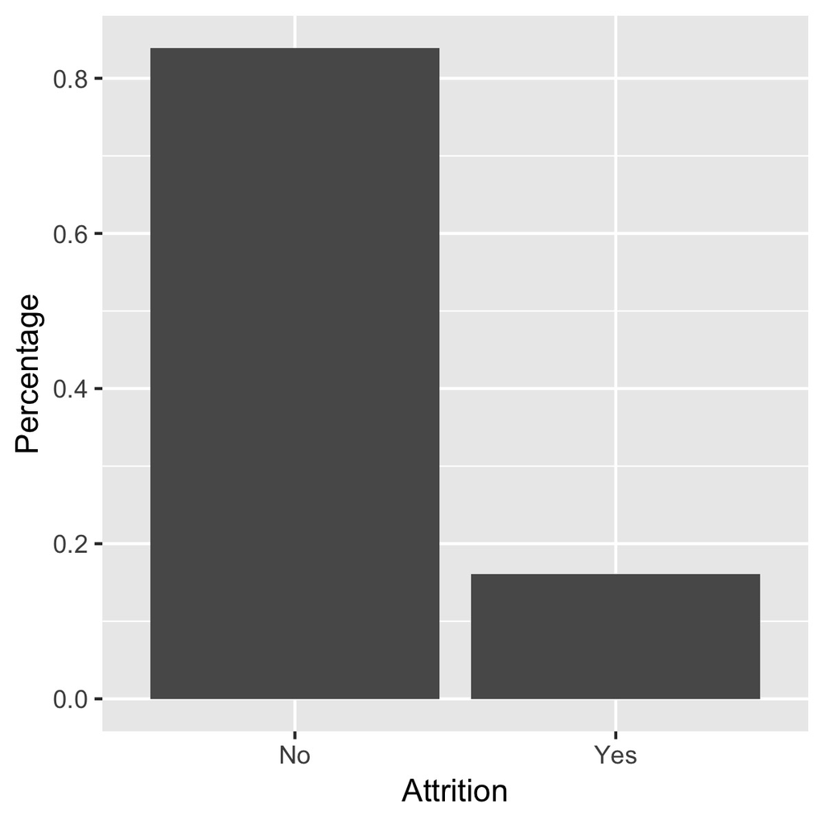

## Data Exploration

- Feature correlations:

```r
cormat_long %>%
  filter(Var1 != Var2, abs(value) > .8) %>%
  arrange(value)
```

```
           Var1              Var2      value
1 MaritalStatus  StockOptionLevel -0.8131347
2    Department           JobRole  0.8508444
3      JobLevel TotalWorkingYears  0.8523883
4      JobLevel     MonthlyIncome  0.9675631
```

Pearson correlations,  
polyserial correlations, and  
polychoric correlations

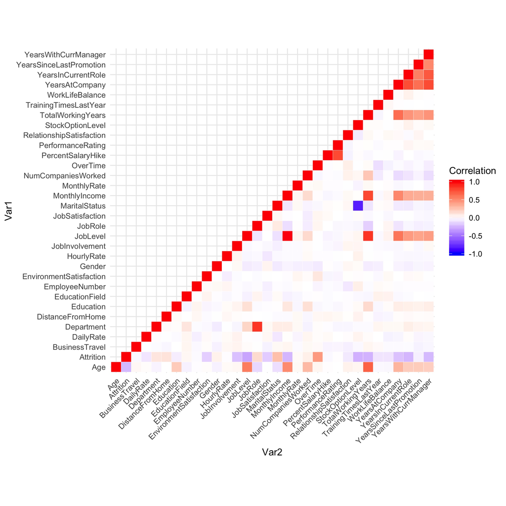

## Features used in the model

- Features used in the model:

```r
varnames_features
```

```
 [1] "Age"                      "BusinessTravel"           "DailyRate"
 [4] "DistanceFromHome"         "Education"                "EducationField"
 [7] "EnvironmentSatisfaction"  "Gender"                   "HourlyRate"
[10] "JobInvolvement"           "JobRole"                  "JobSatisfaction"
[13] "MaritalStatus"            "MonthlyIncome"            "MonthlyRate"
[16] "NumCompaniesWorked"       "OverTime"                 "PercentSalaryHike"
[19] "PerformanceRating"        "RelationshipSatisfaction" "StockOptionLevel"
[22] "TotalWorkingYears"        "TrainingTimesLastYear"    "WorkLifeBalance"
[25] "YearsAtCompany"           "YearsInCurrentRole"       "YearsSinceLastPromotion"
[28] "YearsWithCurrManager"
```

- Features excluded:
  - features with no relevant information: `EmployeeNumber`
  - constant features: `EmployeeCount`, `Over18`, `StandardHours`
  - highly correlated features: `JobLevel`, `Department`

## Categorical variables

- Variable description did not provide scale level
- hence, some features were assumed to be categorical and dummy-coded:

```r
varnames_convert_to_cat
```

```
[1] "WorkLifeBalance"          "StockOptionLevel"         "RelationshipSatisfaction"
[4] "JobSatisfaction"          "JobLevel"                 "JobInvolvement"
[7] "EnvironmentSatisfaction"  "Education"
```

## Train-/Eval-/Test-Split

- Data was split into 3 parts using random sampling:
  - Training set: \(80\%\), \(n = 1180\)
  - Evaluation set: \(10\%\), \(n = 135\)
  - Test set: \(10\%\), \(n = 155\)
- Distribution of target variable in each part remained essentially unchanged:

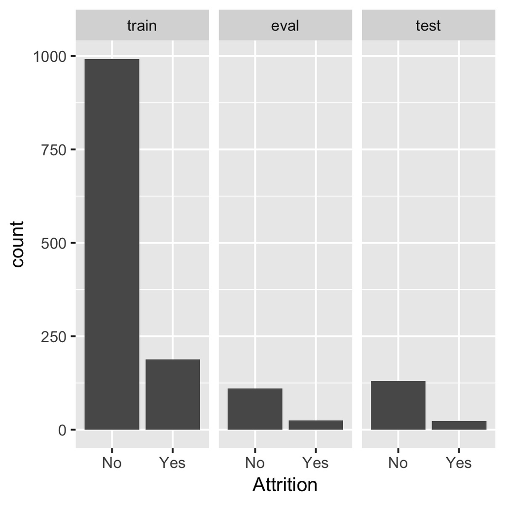

## Upsampling the Training Set

- To balance out the classes, SMOTE sampling was used for the training set
  - Synthetic Minority Oversampling Technique
  - Undersamples the majority class
  - Creates synthetic examples of the minority class
  - by randomly varying the features of \(k\) nearest neighbours (\(k = 5\) in this case)
- Validation and test set remain untouched

```r
set.seed(9560)
formula_smote <- paste0(varnames_target, " ~ .") %>%
  as.formula()
dat_model <- SMOTE(formula_smote,   ##  Attrition ~ .
                   data  = dat_model_imbal %>% as.data.frame())
```

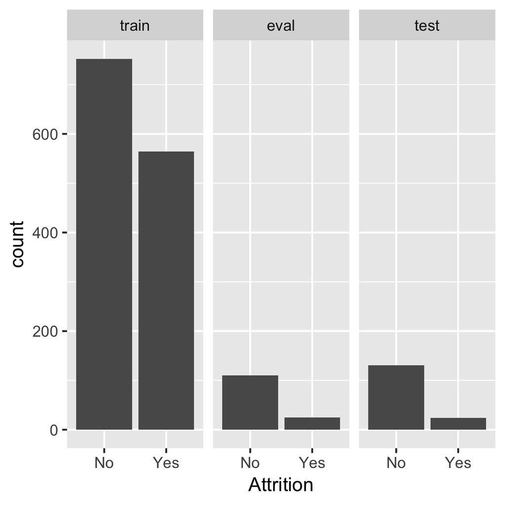

## Machine Learning Models

- A number of models were fitted to the training data:
  - Logistic regression (R’s `base` package)
  - Elastic net regression (`glmnet` package)
  - Random forest (`ranger` package)
  - Boosted GLMs (`glmboost` from the model-based boosting package `mboost`)
  - XGBoost (`xgboost` package)
  - AdaBoost (`adaboost` package)
  - Neural net with 1 hidden layer (`nnet` package)

## Model Fitting

- **Data preparation**: nominal variables were manually dummy-coded for model tuning and (initial) model fitting (necessary for applying XGBoost, unfortunately)
- All model tuning and fitting was performed using the `mlr` package
- **Parameter tuning**: 50 iterations of random search with 6-fold CV within the training set
- **Performance measure**: Matthew’s Correlation Coefficient (MCC)
  - basically is the correlation of true and predicted labels
  - suitable for imbalanced samples

```r
## set random seed, also valid for parallel execution:
set.seed(4271, "L'Ecuyer")

## choose resampling strategy for parameter tuning:
rdesc <- makeResampleDesc(predict = "both",
                          method = "CV", iters = 6)

## parameters for parameter tuning:
n_maxit <- 50
ctrl <- makeTuneControlRandom(maxit = n_maxit)
tune_measures <- list(mcc, auc, f1, bac, acc, mmce, timetrain, timepredict)
```

## Model Fitting and Evaluation

- For **evaluation of performance stability**
  - Models were fitted with 3x repeated 5-fold cross-validation
  - Within the training set
  - Using tuned parameters
- For **evaluation of model performance**
  - Models were re-fitted on the complete training set
  - And performance was evaluated on the evaluation set
- Subset of models was re-fitted on complete training set
  - using non-dummy-coded data
  - for easier model interpretation
- Final **evaluation of performance on the test set**

## Results

## Model Performance Stability

- Performance spread similar for most models
- Higher spread for neural network
- Performance can’t be judged within the training set because of SMOTE-sampling
- Severe overfitting for some models (ranger, XGBoost, AdaBoost, neural net)

```r
bmr_train_summary %>% select(matches("learner|mcc"))
```

```
        learner.id mcc_train.train.mean mcc.test.mean
1   classif.logreg            0.6108784     0.5515077
2   classif.glmnet            0.5985743     0.5406190
3   classif.ranger            0.9632905     0.7085456
4 classif.glmboost            0.6033816     0.5381702
5  classif.xgboost            1.0000000     0.7962943
6      classif.ada            0.9814215     0.7535416
7     classif.nnet            0.8474984     0.5990635
```

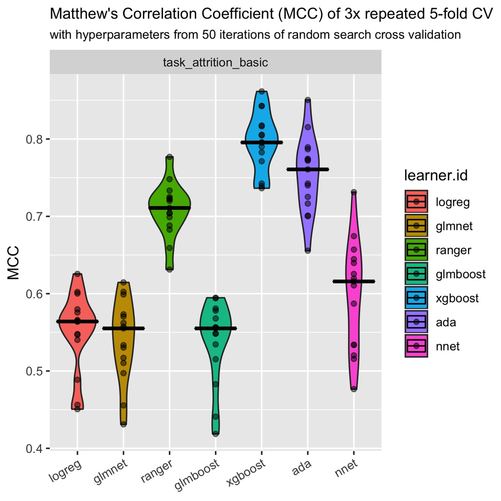

## Performance in Evaluation Set